# Predicting Grades

## The Goal

Create and interpret a logistic regression model that predicts the probability that a student will get an A in Math 325. Needs to have the following criteria:

1. A validation that correctly classifies at least 70% of the predicted grades.
2. A visualization of the model
3. An interpretation of the model

## Logistic Regression

### Exploring the Data

After looking at the pairs plot, I’ve decided to take an elimination approach. Also, since the number of Analyses differ with semester, I’ll only use Total columns. I will be starting with 6 different variables.

```r
glm1 <- glm(FinalGrade == 1 ~ AnalysisTotal + CritiqueTotal + ProjectTotal + SkillsQuizzesTotal + Math325NotebookOrganization + FinalExam, data = grades, family = binomial)
summary(glm1)
```

```
##
## Call:
## glm(formula = FinalGrade == 1 ~ AnalysisTotal + CritiqueTotal +
##     ProjectTotal + SkillsQuizzesTotal + Math325NotebookOrganization +
##     FinalExam, family = binomial, data = grades)
##
## Deviance Residuals:
##        Min          1Q      Median          3Q         Max
## -2.000e-04  -2.100e-08  -2.100e-08   2.100e-08   2.592e-04
##
## Coefficients:
##                              Estimate Std. Error z value Pr(>|z|)
## (Intercept)                  -2877.20  378800.29  -0.008    0.994
## AnalysisTotal                   33.72    4540.59   0.007    0.994
## CritiqueTotal                   14.91   15938.81   0.001    0.999
## ProjectTotal                    31.71    6049.19   0.005    0.996
## SkillsQuizzesTotal              21.92    3137.11   0.007    0.994
## Math325NotebookOrganization    152.48   20191.01   0.008    0.994
## FinalExam                       33.39    4213.17   0.008    0.994
##
## (Dispersion parameter for binomial family taken to be 1)
##
##     Null deviance: 1.6606e+02  on 119  degrees of freedom
## Residual deviance: 1.5061e-07  on 113  degrees of freedom
## AIC: 14
##
## Number of Fisher Scoring iterations: 25
```

The p-values don’t look too good. I’m going to remove the worst one, CritiqueTotal.

```r
glm2 <- glm(FinalGrade == 1 ~ AnalysisTotal + ProjectTotal + SkillsQuizzesTotal + Math325NotebookOrganization + FinalExam, data = grades, family = binomial)
summary(glm2)
```

```
##
## Call:
## glm(formula = FinalGrade == 1 ~ AnalysisTotal + ProjectTotal +
##     SkillsQuizzesTotal + Math325NotebookOrganization + FinalExam,
##     family = binomial, data = grades)
##
## Deviance Residuals:
##        Min          1Q      Median          3Q         Max
## -2.360e-04  -2.100e-08  -2.100e-08   2.100e-08   2.485e-04
##
## Coefficients:
##                              Estimate Std. Error z value Pr(>|z|)
## (Intercept)                  -3633.71  376228.64  -0.010    0.992
## AnalysisTotal                   37.39    6373.11   0.006    0.995
## ProjectTotal                    65.68    9528.40   0.007    0.995
## SkillsQuizzesTotal              25.27    3192.12   0.008    0.994
## Math325NotebookOrganization    188.69   20599.03   0.009    0.993
## FinalExam                       41.88    5655.31   0.007    0.994
##
## (Dispersion parameter for binomial family taken to be 1)
##
##     Null deviance: 1.6606e+02  on 119  degrees of freedom
## Residual deviance: 2.4099e-07  on 114  degrees of freedom
## AIC: 12
##
## Number of Fisher Scoring iterations: 25
```

Again, significance isn’t looking good. I’m going to remove ProjectTotal and see what that does.

```r
glm3 <- glm(FinalGrade == 1 ~ AnalysisTotal + SkillsQuizzesTotal + Math325NotebookOrganization + FinalExam, data = grades, family = binomial)
summary(glm3)
```

```
##
## Call:
## glm(formula = FinalGrade == 1 ~ AnalysisTotal + SkillsQuizzesTotal +
##     Math325NotebookOrganization + FinalExam, family = binomial,
##     data = grades)
##
## Deviance Residuals:
##      Min        1Q    Median        3Q       Max
## -2.57917  -0.00840   0.00000   0.03499   1.49938
##
## Coefficients:
##                              Estimate Std. Error z value Pr(>|z|)
## (Intercept)                 -112.9468    36.9899  -3.053  0.00226 **
## AnalysisTotal                  2.1920     0.7957   2.755  0.00587 **
## SkillsQuizzesTotal             1.2711     0.4433   2.867  0.00414 **
## Math325NotebookOrganization    5.2156     2.2257   2.343  0.01911 *
## FinalExam                      1.1243     0.3690   3.047  0.00231 **
## ---
## Signif. codes:  0 '***' 0.001 '**' 0.01 '*' 0.05 '.' 0.1 ' ' 1
##
## (Dispersion parameter for binomial family taken to be 1)
##
##     Null deviance: 166.055  on 119  degrees of freedom
## Residual deviance:  20.552  on 115  degrees of freedom
## AIC: 30.552
##
## Number of Fisher Scoring iterations: 11
```

Much Better. I’m going to check interactions now to see if I can’t get the AIC down from 30.552.

```r
glm4 <- glm(FinalGrade == 1 ~ (AnalysisTotal + SkillsQuizzesTotal + Math325NotebookOrganization + FinalExam)^2, data = grades, family = binomial)
summary(glm4)
```

```
##
## Call:
## glm(formula = FinalGrade == 1 ~ (AnalysisTotal + SkillsQuizzesTotal +
##     Math325NotebookOrganization + FinalExam)^2, family = binomial,
##     data = grades)
##
## Deviance Residuals:
##        Min          1Q      Median          3Q         Max
## -1.699e-04  -2.100e-08  -2.100e-08   2.100e-08   1.294e-04
##
## Coefficients:
##                                                  Estimate Std. Error
## (Intercept)                                        382.29 1138354.34
## AnalysisTotal                                     -350.05   70764.57
## SkillsQuizzesTotal                                 152.24  161782.91
## Math325NotebookOrganization                        886.44  168462.32
## FinalExam                                          -91.60  169813.53
## AnalysisTotal:SkillsQuizzesTotal                     2.45     863.93
## AnalysisTotal:Math325NotebookOrganization           33.87   12483.52
## AnalysisTotal:FinalExam                             19.57    3811.89
## SkillsQuizzesTotal:Math325NotebookOrganization     -44.85   22524.37
## SkillsQuizzesTotal:FinalExam                         2.00    5257.00
## Math325NotebookOrganization:FinalExam              -88.80   20696.66
##                                                z value Pr(>|z|)
## (Intercept)                                      0.000    1.000
## AnalysisTotal                                   -0.005    0.996
## SkillsQuizzesTotal                               0.001    0.999
## Math325NotebookOrganization                      0.005    0.996
## FinalExam                                       -0.001    1.000
## AnalysisTotal:SkillsQuizzesTotal                 0.003    0.998
## AnalysisTotal:Math325NotebookOrganization        0.003    0.998
## AnalysisTotal:FinalExam                          0.005    0.996
## SkillsQuizzesTotal:Math325NotebookOrganization  -0.002    0.998
## SkillsQuizzesTotal:FinalExam                     0.000    1.000
## Math325NotebookOrganization:FinalExam           -0.004    0.997
##
## (Dispersion parameter for binomial family taken to be 1)
##
##     Null deviance: 1.6606e+02  on 119  degrees of freedom
## Residual deviance: 8.3308e-08  on 109  degrees of freedom
## AIC: 22
##
## Number of Fisher Scoring iterations: 25
```

```r
glm5 <- glm(FinalGrade == 1 ~ AnalysisTotal + SkillsQuizzesTotal + Math325NotebookOrganization + FinalExam + AnalysisTotal:SkillsQuizzesTotal + AnalysisTotal:Math325NotebookOrganization + AnalysisTotal:FinalExam + SkillsQuizzesTotal:Math325NotebookOrganization + Math325NotebookOrganization:FinalExam, data = grades, family = binomial)
summary(glm5)
```

```
##
## Call:
## glm(formula = FinalGrade == 1 ~ AnalysisTotal + SkillsQuizzesTotal +
##     Math325NotebookOrganization + FinalExam + AnalysisTotal:SkillsQuizzesTotal +
##     AnalysisTotal:Math325NotebookOrganization + AnalysisTotal:FinalExam +
##     SkillsQuizzesTotal:Math325NotebookOrganization + Math325NotebookOrganization:FinalExam,
##     family = binomial, data = grades)
##
## Deviance Residuals:
##        Min          1Q      Median          3Q         Max
## -1.846e-04  -2.100e-08  -2.100e-08   2.100e-08   1.769e-04
##
## Coefficients:
##                                                  Estimate Std. Error
## (Intercept)                                        18.422 327236.512
## AnalysisTotal                                    -370.191  59833.895
## SkillsQuizzesTotal                                206.750  57846.875
## Math325NotebookOrganization                       920.535 157146.974
## FinalExam                                         -36.844  42882.007
## AnalysisTotal:SkillsQuizzesTotal                    2.477   1049.211
## AnalysisTotal:Math325NotebookOrganization          37.880   7258.670
## AnalysisTotal:FinalExam                            19.325   3304.727
## SkillsQuizzesTotal:Math325NotebookOrganization    -52.304   9995.686
## Math325NotebookOrganization:FinalExam             -94.087  17091.170
##                                                z value Pr(>|z|)
## (Intercept)                                      0.000    1.000
## AnalysisTotal                                   -0.006    0.995
## SkillsQuizzesTotal                               0.004    0.997
## Math325NotebookOrganization                      0.006    0.995
## FinalExam                                       -0.001    0.999
## AnalysisTotal:SkillsQuizzesTotal                 0.002    0.998
## AnalysisTotal:Math325NotebookOrganization        0.005    0.996
## AnalysisTotal:FinalExam                          0.006    0.995
## SkillsQuizzesTotal:Math325NotebookOrganization  -0.005    0.996
## Math325NotebookOrganization:FinalExam           -0.006    0.996
##
## (Dispersion parameter for binomial family taken to be 1)
##
##     Null deviance: 1.6606e+02  on 119  degrees of freedom
## Residual deviance: 8.9700e-08  on 110  degrees of freedom
## AIC: 20
##
## Number of Fisher Scoring iterations: 25
```

```r
glm6 <- glm(FinalGrade == 1 ~ AnalysisTotal + SkillsQuizzesTotal + Math325NotebookOrganization:FinalExam, data = grades, family = binomial)
summary(glm6)
```

```
##
## Call:
## glm(formula = FinalGrade == 1 ~ AnalysisTotal + SkillsQuizzesTotal +
##     Math325NotebookOrganization:FinalExam, family = binomial,
##     data = grades)
##
## Deviance Residuals:
##      Min        1Q    Median        3Q       Max
## -2.59191  -0.01668   0.00000   0.04727   1.34430
##
## Coefficients:
##                                        Estimate Std. Error z value
## (Intercept)                           -79.58334   24.69232  -3.223
## AnalysisTotal                           1.97050    0.65257   3.020
## SkillsQuizzesTotal                      1.10604    0.39827   2.777
## Math325NotebookOrganization:FinalExam   0.22625    0.07075   3.198
##                                       Pr(>|z|)
## (Intercept)                            0.00127 **
## AnalysisTotal                          0.00253 **
## SkillsQuizzesTotal                     0.00548 **
## Math325NotebookOrganization:FinalExam  0.00138 **
## ---
## Signif. codes:  0 '***' 0.001 '**' 0.01 '*' 0.05 '.' 0.1 ' ' 1
##
## (Dispersion parameter for binomial family taken to be 1)
##
##     Null deviance: 166.055  on 119  degrees of freedom
## Residual deviance:  23.815  on 116  degrees of freedom
## AIC: 31.815
##
## Number of Fisher Scoring iterations: 10
```

After finding a model that was significant that included interactions, I found that the AIC was worst that the model that had no interactions, so I’m going to go back to the original model. I’m going to look at a pairs plot with just these variables to make sure that I’m not missing anything.

```r
glm3 <- glm(FinalGrade == 1 ~ AnalysisTotal + SkillsQuizzesTotal + Math325NotebookOrganization + FinalExam, data = grades, family = binomial)
summary(glm3)
```

```
##
## Call:
## glm(formula = FinalGrade == 1 ~ AnalysisTotal + SkillsQuizzesTotal +
##     Math325NotebookOrganization + FinalExam, family = binomial,
##     data = grades)
##
## Deviance Residuals:
##      Min        1Q    Median        3Q       Max
## -2.57917  -0.00840   0.00000   0.03499   1.49938
##
## Coefficients:
##                              Estimate Std. Error z value Pr(>|z|)
## (Intercept)                 -112.9468    36.9899  -3.053  0.00226 **
## AnalysisTotal                  2.1920     0.7957   2.755  0.00587 **
## SkillsQuizzesTotal             1.2711     0.4433   2.867  0.00414 **
## Math325NotebookOrganization    5.2156     2.2257   2.343  0.01911 *
## FinalExam                      1.1243     0.3690   3.047  0.00231 **
## ---
## Signif. codes:  0 '***' 0.001 '**' 0.01 '*' 0.05 '.' 0.1 ' ' 1
##
## (Dispersion parameter for binomial family taken to be 1)
##
##     Null deviance: 166.055  on 119  degrees of freedom
## Residual deviance:  20.552  on 115  degrees of freedom
## AIC: 30.552
##
## Number of Fisher Scoring iterations: 11
```

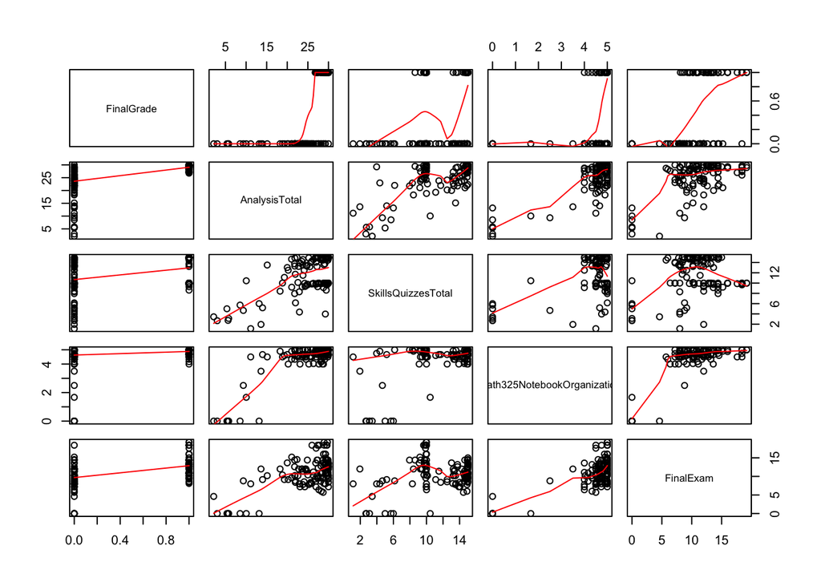

```r
pairs(grades[,c(2,18,33,35,37)], panel = panel.smooth)
```

Something weird is going on with SkillsQuizzesTotal. It would appear that there are two possible total scores, 10 and 15. Taking out SkilssQuizzesTotal would increase the AIC to 49.656. I’m going to determine the semesters and create a new column that weights everything correctly.

```r
grades1 <- grades %>%
  mutate(skillsQuizTotalPerc = case_when(
    is.na(Critique12) ~ SkillsQuizzesTotal/15,
    TRUE ~ SkillsQuizzesTotal/10
  ))

glm7 <- glm(FinalGrade == 1 ~ AnalysisTotal + skillsQuizTotalPerc + Math325NotebookOrganization + FinalExam, data = grades1, family = binomial)
summary(glm7)
```

```
##
## Call:
## glm(formula = FinalGrade == 1 ~ AnalysisTotal + skillsQuizTotalPerc +
##     Math325NotebookOrganization + FinalExam, family = binomial,
##     data = grades1)
##
## Deviance Residuals:
##      Min        1Q    Median        3Q       Max
## -2.36807  -0.05995   0.00000   0.18711   1.57948
##
## Coefficients:
##                             Estimate Std. Error z value Pr(>|z|)
## (Intercept)                 -59.1583    14.9338  -3.961 7.45e-05 ***
## AnalysisTotal                 1.3136     0.3386   3.880 0.000104 ***
## skillsQuizTotalPerc           7.6833     7.0464   1.090 0.275541
## Math325NotebookOrganization   2.3420     1.3475   1.738 0.082218 .
## FinalExam                     0.4303     0.1598   2.693 0.007079 **
## ---
## Signif. codes:  0 '***' 0.001 '**' 0.01 '*' 0.05 '.' 0.1 ' ' 1
##
## (Dispersion parameter for binomial family taken to be 1)
##
##     Null deviance: 166.055  on 119  degrees of freedom
## Residual deviance:  38.829  on 115  degrees of freedom
## AIC: 48.829
##
## Number of Fisher Scoring iterations: 9
```

Well that is interesting. The glm doesn’t like SkillsQuizzes anymore as you can see. I will remove that and try ProjectTotal again..

```r
glm8 <- glm(FinalGrade == 1 ~ AnalysisTotal + ProjectTotal + Math325NotebookOrganization + FinalExam, data = grades1, family = binomial)
summary(glm8)
```

```
##
## Call:
## glm(formula = FinalGrade == 1 ~ AnalysisTotal + ProjectTotal +
##     Math325NotebookOrganization + FinalExam, family = binomial,
##     data = grades1)
##
## Deviance Residuals:
##      Min        1Q    Median        3Q       Max
## -2.39740  -0.06402   0.00000   0.11274   1.82254
##
## Coefficients:
##                             Estimate Std. Error z value Pr(>|z|)
## (Intercept)                 -76.9036    21.3978  -3.594 0.000326 ***
## AnalysisTotal                 1.2564     0.3045   4.126 3.69e-05 ***
## ProjectTotal                  1.2659     0.6129   2.066 0.038873 *
## Math325NotebookOrganization   3.0372     1.7563   1.729 0.083750 .
## FinalExam                     0.9124     0.3161   2.886 0.003902 **
## ---
## Signif. codes:  0 '***' 0.001 '**' 0.01 '*' 0.05 '.' 0.1 ' ' 1
##
## (Dispersion parameter for binomial family taken to be 1)
##
##     Null deviance: 166.055  on 119  degrees of freedom
## Residual deviance:  32.383  on 115  degrees of freedom
## AIC: 42.383
##
## Number of Fisher Scoring iterations: 10
```

Notebook Organization is no longer important, removing that variable.

```r
glm8 <- glm(FinalGrade == 1 ~ AnalysisTotal + ProjectTotal + FinalExam, data = grades1, family = binomial)
summary(glm8)
```

```
##
## Call:
## glm(formula = FinalGrade == 1 ~ AnalysisTotal + ProjectTotal +
##     FinalExam, family = binomial, data = grades1)
##
## Deviance Residuals:
##      Min        1Q    Median        3Q       Max
## -3.03757  -0.07688   0.00000   0.15275   2.01552
##
## Coefficients:
##               Estimate Std. Error z value Pr(>|z|)
## (Intercept)   -58.5917    15.0184  -3.901 9.57e-05 ***
## AnalysisTotal   1.1845     0.2739   4.325 1.53e-05 ***
## ProjectTotal    1.1968     0.7020   1.705  0.08823 .
## FinalExam       0.8192     0.2494   3.284  0.00102 **
## ---
## Signif. codes:  0 '***' 0.001 '**' 0.01 '*' 0.05 '.' 0.1 ' ' 1
##
## (Dispersion parameter for binomial family taken to be 1)
##
##     Null deviance: 166.055  on 119  degrees of freedom
## Residual deviance:  35.759  on 116  degrees of freedom
## AIC: 43.759
##
## Number of Fisher Scoring iterations: 10
```

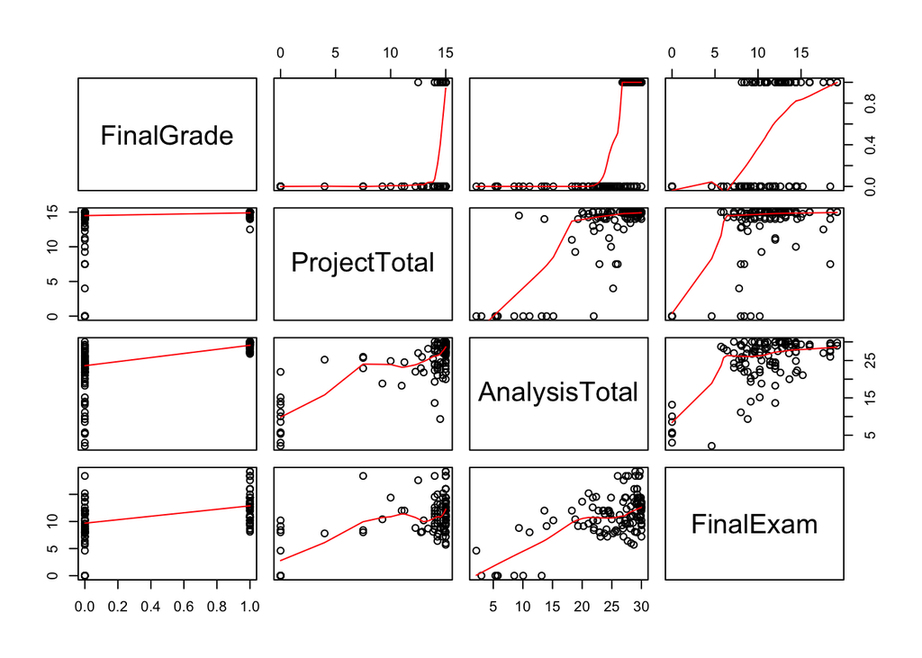

```r
pairs(grades[,c(2,5,18,37)], panel = panel.smooth)
```

This is the model that I’ll work with. See next tab for Goodness of Fit.

### Chosen Model/Fit

As determined in the ‘Exploring the Data’ tab, my model is:

```r
summary(glm8)
```

```
##
## Call:
## glm(formula = FinalGrade == 1 ~ AnalysisTotal + ProjectTotal +
##     FinalExam, family = binomial, data = grades1)
##
## Deviance Residuals:
##      Min        1Q    Median        3Q       Max
## -3.03757  -0.07688   0.00000   0.15275   2.01552
##
## Coefficients:
##               Estimate Std. Error z value Pr(>|z|)
## (Intercept)   -58.5917    15.0184  -3.901 9.57e-05 ***
## AnalysisTotal   1.1845     0.2739   4.325 1.53e-05 ***
## ProjectTotal    1.1968     0.7020   1.705  0.08823 .
## FinalExam       0.8192     0.2494   3.284  0.00102 **
## ---
## Signif. codes:  0 '***' 0.001 '**' 0.01 '*' 0.05 '.' 0.1 ' ' 1
##
## (Dispersion parameter for binomial family taken to be 1)
##
##     Null deviance: 166.055  on 119  degrees of freedom
## Residual deviance:  35.759  on 116  degrees of freedom
## AIC: 43.759
##
## Number of Fisher Scoring iterations: 10
```

#### Goodness of Fit Test

Running the Hoslem Goodness of Fit Test we get the following results:

```r
hoslem.test(glm8$y, glm8$fitted.values, g = 10)
```

```
##
##  Hosmer and Lemeshow goodness of fit (GOF) test
##
## data:  glm8$y, glm8$fitted.values
## X-squared = 4.2136, df = 8, p-value = 0.8374
```

Since our p-value is not significant we can assume that we have a good fitting model. See ‘Validation’ tab for model Validation.

### Validation

I’m now going to create a train and test set to create predictions.

```r
set.seed(353)
keep <- sample(1:nrow(grades), 60)
mytrain <- grades[keep,]
mytest <- grades[-keep,]

train.glm <-  glm(FinalGrade == 1 ~ AnalysisTotal + ProjectTotal + FinalExam, data=mytrain, family=binomial)
predict(train.glm, newdata = mytest, type = "response")
```

```
##            1            4            6            7           13
## 6.133123e-10 2.220446e-16 5.892086e-01 9.999895e-01 7.646824e-01
##           14           16           17           20           21
## 9.632999e-01 3.176589e-08 2.220446e-16 2.113851e-06 9.885188e-01
##           22           24           25           26           27
## 9.239246e-03 9.540080e-01 1.372651e-08 8.798126e-01 8.591355e-04
##           29           30           32           33           37
## 9.998901e-01 6.925082e-04 2.144215e-03 9.418638e-01 8.746029e-06
##           39           40           42           43           44
## 9.620822e-01 9.999916e-01 6.632149e-04 2.220446e-16 2.220446e-16
##           45           47           48           49           52
## 9.999900e-01 2.220446e-16 9.966502e-01 6.757367e-04 3.082079e-01
##           53           54           56           59           60
## 2.220446e-16 9.854885e-01 2.032921e-11 9.986550e-01 9.993247e-01
##           61           62           64           68           69
## 2.220446e-16 9.905477e-01 9.733881e-01 9.993540e-01 9.997127e-01
##           70           72           73           74           76
## 9.969996e-01 1.742705e-01 1.433259e-01 9.877990e-01 5.728706e-01
##           79           82           85           90           94
## 2.235976e-02 9.994425e-01 2.220446e-16 9.998734e-01 9.886935e-01
##           97           98          100          101          102
## 9.926400e-01 9.714539e-01 1.609585e-02 2.220446e-16 2.220446e-16
##          107          108          110          112          113
## 9.998420e-01 7.237881e-05 8.636287e-02 5.118105e-02 9.892579e-01
```

```r
preds <- ifelse(predict(train.glm, newdata = mytest, type = "response") > .7, 1, 0)

table(preds, mytest$FinalGrade)
```

```
##
## preds  0  1
##     0 30  2
##     1  2 26
```

Checking my accuracy, I get the following result:

```r
(30+26) / (2+2+26+30)
```

```
## [1] 0.9333333
```

This isn’t bad and is above the .7 required.

### Conclusion

```r
# summary(grades$AnalysisTotal)
# summary(grades$ProjectTotal)
# summary(grades$FinalExam)
par(mfrow = c(1,1))
```

#### Analysis Total Score

The graph below shows the probability of you getting an A according to your Analysis Total, if you scored a 50%, 75%, or 100% on your both your Project Total and Final Exam grade.

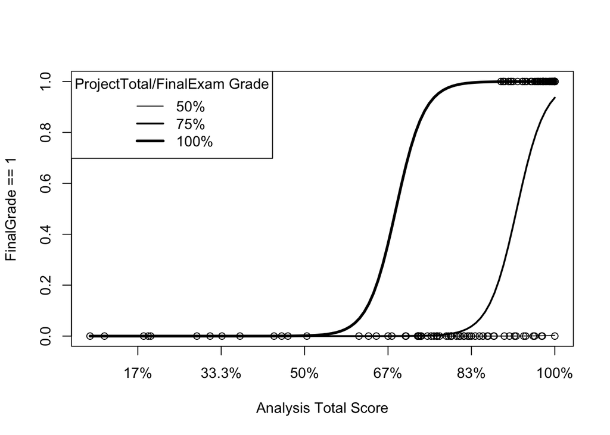

```r
plot(FinalGrade == 1 ~ AnalysisTotal, data=grades, xaxt='n', xlab="Analysis Total Score")
axis(1, at=seq(5,30,5), labels=c("17%","33.3%","50%","67%","83%","100%"))
b <- coef(glm8)

ProjectTotal=7.5;FinalExam=10;
curve(exp(b[1] + b[2]*AnalysisTotal + b[3]*ProjectTotal + b[4]*FinalExam)/(1+ exp(b[1] + b[2]*AnalysisTotal + b[3]*ProjectTotal + b[4]*FinalExam)), xname="AnalysisTotal", add=TRUE, lwd=1)

ProjectTotal=11.25;FinalExam=15;
curve(exp(b[1] + b[2]*AnalysisTotal + b[3]*ProjectTotal + b[4]*FinalExam)/(1+ exp(b[1] + b[2]*AnalysisTotal + b[3]*ProjectTotal + b[4]*FinalExam)), xname="AnalysisTotal", add=TRUE, lwd=2)

ProjectTotal=15;FinalExam=20;
curve(exp(b[1] + b[2]*AnalysisTotal + b[3]*ProjectTotal + b[4]*FinalExam)/(1+ exp(b[1] + b[2]*AnalysisTotal + b[3]*ProjectTotal + b[4]*FinalExam)), xname="AnalysisTotal", add=TRUE, lwd=3)
legend("topleft", legend=c("50%", "75%", "100%"), title="ProjectTotal/FinalExam Grade", lwd=c(1,2,3))
```

As you can see, if you received a 50% on your Final Exam and on your Project Total, the probability of you getting an A is 0 no matter what you score on your Analysis Total. As you’re scores for your Project Total and Final Exam go up, so do your chances of getting an A without a perfect score on your Analysis.

To be more precise, you are 3.2689554 times more likely to get an “A” for every point scored in your AnalysisTotal.

#### Project Total Score

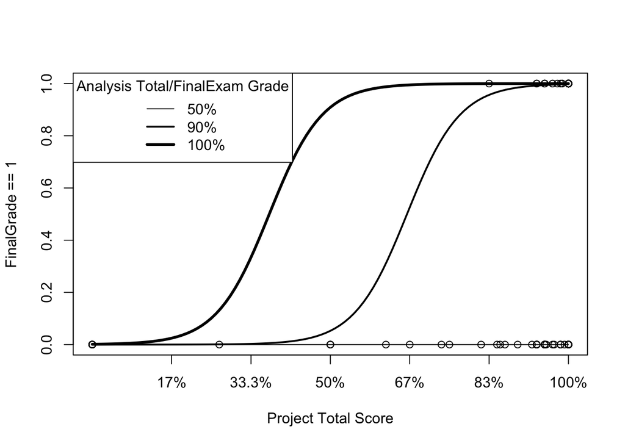

```r
plot(FinalGrade == 1 ~ ProjectTotal, data=grades, xaxt='n', xlab="Project Total Score")
axis(1, at=seq(2.5,15,2.5), labels=c("17%","33.3%","50%","67%","83%","100%"))
b <- coef(glm8)

AnalysisTotal=15;FinalExam=10;
curve(exp(b[1] + b[2]*AnalysisTotal + b[3]*ProjectTotal + b[4]*FinalExam)/(1+ exp(b[1] + b[2]*AnalysisTotal + b[3]*ProjectTotal + b[4]*FinalExam)), xname="ProjectTotal", add=TRUE, lwd=1)

AnalysisTotal=27;FinalExam=18;
curve(exp(b[1] + b[2]*AnalysisTotal + b[3]*ProjectTotal + b[4]*FinalExam)/(1+ exp(b[1] + b[2]*AnalysisTotal + b[3]*ProjectTotal + b[4]*FinalExam)), xname="ProjectTotal", add=TRUE, lwd=2)

AnalysisTotal=30;FinalExam=20;
curve(exp(b[1] + b[2]*AnalysisTotal + b[3]*ProjectTotal + b[4]*FinalExam)/(1+ exp(b[1] + b[2]*AnalysisTotal + b[3]*ProjectTotal + b[4]*FinalExam)), xname="ProjectTotal", add=TRUE, lwd=3)
legend("topleft", legend=c("50%", "90%", "100%"), title="Analysis Total/FinalExam Grade", lwd=c(1,2,3))
```

As you can see, if you received a 50% on your Final Exam and on your Analysis Total, the probability of you getting an A is 0 no matter what you score on your Project Total. As you’re scores for your Analysis Total and Final Exam go up, so do your chances of getting an A without a perfect score on your Project Total.

To be more precise, you are 3.309357 times more likely to get an “A” for every point scored in your ProjectTotal.

#### Final Exam Grade

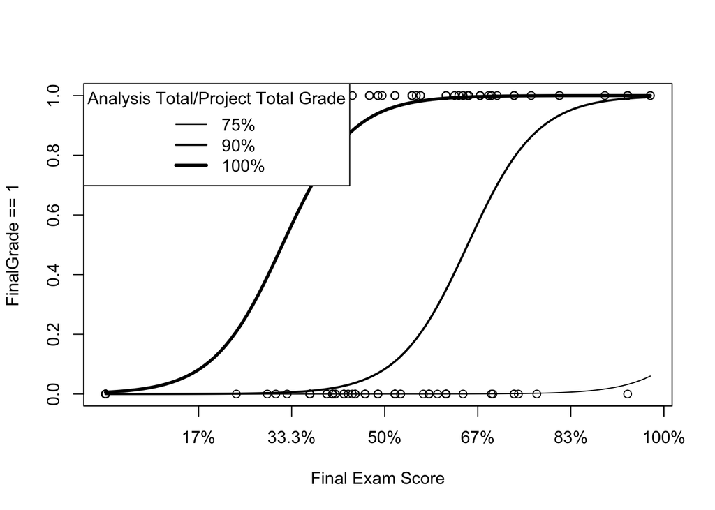

```r
plot(FinalGrade == 1 ~ FinalExam, data=grades, xaxt='n', xlab="Final Exam Score")
axis(1, at=seq(3.28,20,3.28), labels=c("17%","33.3%","50%","67%","83%","100%"))
b <- coef(glm8)

AnalysisTotal=22.5;ProjectTotal=11.25;
curve(exp(b[1] + b[2]*AnalysisTotal + b[3]*ProjectTotal + b[4]*FinalExam)/(1+ exp(b[1] + b[2]*AnalysisTotal + b[3]*ProjectTotal + b[4]*FinalExam)), xname="FinalExam", add=TRUE, lwd=1)

AnalysisTotal=27;ProjectTotal=13.5;
curve(exp(b[1] + b[2]*AnalysisTotal + b[3]*ProjectTotal + b[4]*FinalExam)/(1+ exp(b[1] + b[2]*AnalysisTotal + b[3]*ProjectTotal + b[4]*FinalExam)), xname="FinalExam", add=TRUE, lwd=2)

AnalysisTotal=30;ProjectTotal=15;
curve(exp(b[1] + b[2]*AnalysisTotal + b[3]*ProjectTotal + b[4]*FinalExam)/(1+ exp(b[1] + b[2]*AnalysisTotal + b[3]*ProjectTotal + b[4]*FinalExam)), xname="FinalExam", add=TRUE, lwd=3)
legend("topleft", legend=c("75%", "90%", "100%"), title="Analysis Total/Project Total Grade", lwd=c(1,2,3))
```

As you can see, if you received a 75% on your Project Total and on your Analysis Total, the probability of you getting an A is close to 0 no matter what you score on your Final Exam. As you’re scores for your Project Total and Analysis Total go up, so do your chances of getting an A without a perfect score on your Final Exam.

To be more precise, you are 2.2686568 times more likely to get an “A” for every point scored in your FinalExam.

### Recommendations

Dear Math 325 Student,

After analyzing grades of past students, I have determined different areas that largely affect your Final grade. They are:

- Analysis Total Grade
- Project Total Grade
- Final Exam Grade

From the resulting regression model created, I want to emphasize the odds of each area in getting A.

As you can see, all three of these areas are very important and will increase your odds of getting an A. However, doing well on your Projects and Analyses exhibit the best of the odds. Therefore, I would recommend putting great effort and doing well on those and the grade will take care of it self.

Good luck!

```r
test_grades <- read.csv('Math325Grades_Test.csv')

test_grades$FinalGrade <- ifelse(predict(glm8, test_grades, type="response") > .7, "A", "Other")

write.csv(test_grades, "Test.csv", row.names=FALSE)
```